# Homework 9

Solutions

# Preliminaries

- This file should be in `STAT240/homework/hw09` on your local computer.

# Problem 1

Consider drawing a sample of size $n_1 = 60$ from a binary population with proportion $p_1 = 0.3$ of 1’s. Also consider drawing a sample of size $n_2 = 55$ from a population with proportion $p_2 = 0.4$ of 1’s.

1. Write code to generate 10000 simulations of the sampling distribution of $\hat{p}_1 - \hat{p}_2$, the difference in sample proportions.

```r
simulations <- tibble(
  phat1 = replicate(10000, mean(sample(0:1, size = 60,
                                  replace = T, prob = c(0.7, 0.3)))),
  phat2 = replicate(10000, mean(sample(0:1, size = 55,
                                  replace = T, prob = c(0.6, 0.4)))),
  diff = phat1 - phat2
)
```

2. Create a histogram of the results of the simulation, and report the mean and standard deviation of the 10000 resamples.

```r
simulations %>%
  summarize(mean_diff = mean(diff), sd_diff = sd(diff))
```

```
## # A tibble: 1 × 2
##   mean_diff sd_diff
##       <dbl>   <dbl>
## 1    -0.101  0.0904
```

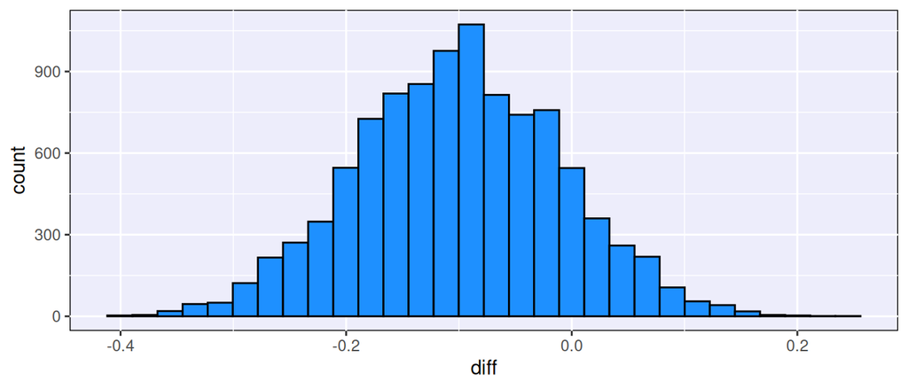

```r
ggplot(simulations, aes(x = diff)) +
  geom_histogram(color = "black", fill = "dodgerblue")
```

The shape is approximately normal.

3. Now, describe the sampling distribution of $\hat{p}_1 - \hat{p}_2$ with the normal approximation. Do the shape, mean and standard deviation of the resamples in (b) match the theoretical model?

Under the normal approximation,
$$\hat{p}_1 - \hat{p}_2 \;\dot{\sim}\; N\Big(p_1 -
p_2, \sqrt{\frac{p_1(1-p_1)}{n1} + \frac{p_2(1-p_2)}{n_2}}\Big) \;=\;
N(-0.1, 0.0887).$$
The mean, standard deviation, and shape of the sampling distribution of $\hat{p}_1 - \hat{p}_2$ match closely to the empirical simulation.

4. Repeat parts (a) through (c), but set $n_1 = 5$ and $n_2 = 5$. How do the shape, mean, and standard deviation of the simulation and theoretical model compare?

```r
simulations <- tibble(
  phat1 = replicate(10000, mean(sample(0:1, size = 5,
                                  replace = T, prob = c(0.7, 0.3)))),
  phat2 = replicate(10000, mean(sample(0:1, size = 5,
                                  replace = T, prob = c(0.6, 0.4)))),
  diff = phat1 - phat2
)

simulations %>%
  summarize(mean_diff = mean(diff), sd_diff = sd(diff))
```

```
## # A tibble: 1 × 2
##   mean_diff sd_diff
##       <dbl>   <dbl>
## 1   -0.0994   0.296
```

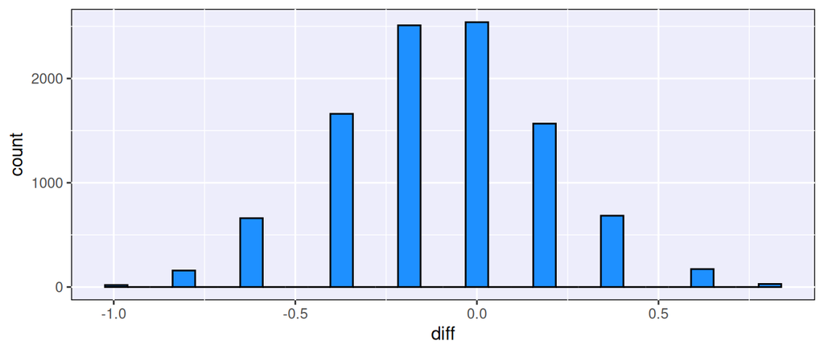

```r
ggplot(simulations, aes(x = diff)) +
  geom_histogram(color = "black", fill = "dodgerblue")
```

The new normal approximation is,
$$\hat{p}_1 - \hat{p}_2 \;\dot{\sim}\; N\Big(p_1 -
p_2, \sqrt{\frac{p_1(1-p_1)}{n1} + \frac{p_2(1-p_2)}{n_2}}\Big) \;=\;
N(-0.1, 0.3).$$
The mean and standard deviation of the sampling distribution of $\hat{p}_1 - \hat{p}_2$ match closely to the empirical simulation, but the simulated values no longer look normal since they do not look continuous.

# Problem 2

(Fictional data): In a survey done in 2000, 63 out of 500 American households reported serving only vegetarian or vegan dishes for Thanksgiving. In a similar survey done in 2024, the number of reported households serving only vegetarian or vegan dishes was 116 out of 500.

Based on this data, a Z confidence interval for a difference in proportions (2000 - 2024) was reported as

$$(-0.1455, -0.0665)$$

Identify the confidence level that was used to create this interval.

The interval was made with the formula point estimate $\pm$ critical value $\times$ standard error, where the critical value was determined by the confidence level. So, we need to solve for the critical value. This is the margin of error divided by the (AC-adjusted) standard error.

```r
# Margin of error: half-width of interval
moe <- (-0.0665 + 0.1455) / 2

# Observed proportions and standard error
x1 <- 63; x2 <- 116
n1 <- 500; n2 <- 500

phat1 <- x1/n1; phat2 <- x2/n2

se <- sqrt(phat1*(1-phat1)/n1 + phat2*(1-phat2)/n2)

# Solve for critical value
cv <- moe / se
cv
```

```
## [1] 1.644977
```

The critical value/multiplier used to create the interval is about 1.645. So, 1.645 is the quantile that cuts off $\alpha/2$ area in the upper tail of the standard normal curve. To find $\alpha/2$, use `pnorm()`.

```r
pnorm(cv, lower.tail = F)
```

```
## [1] 0.0499873
```

We get $\alpha/2 = 0.05$ which means $\alpha = 0.1$. This corresponds to 90% confidence. We can re-create the original interval with `qnorm(0.95)`.

```r
original_cv <- qnorm(0.95)

pt_est <- phat1 - phat2

c(pt_est - original_cv*se, pt_est + original_cv*se)
```

```
## [1] -0.14549704 -0.06650296
```

# Problem 3

The “[returning soldier effect](https://en.wikipedia.org/wiki/Returning_soldier_effect)” is a phenemonon where more boys are born immediately following crises such as war.

In the year 1940, before the US joined World War II, there were 1211684 male and 1148715 female live births in the US. In the year 1946, after WWII ended, there were 1691220 male and 1597452 female live births in the US.

1. Use `geom_col()` to create a bar graph showing the proportion of boys born in 1940 versus 1946. Add the layer `coord_cartesian(ylim = c(0, 1))` to force the y-axis to go from 0 to 1.

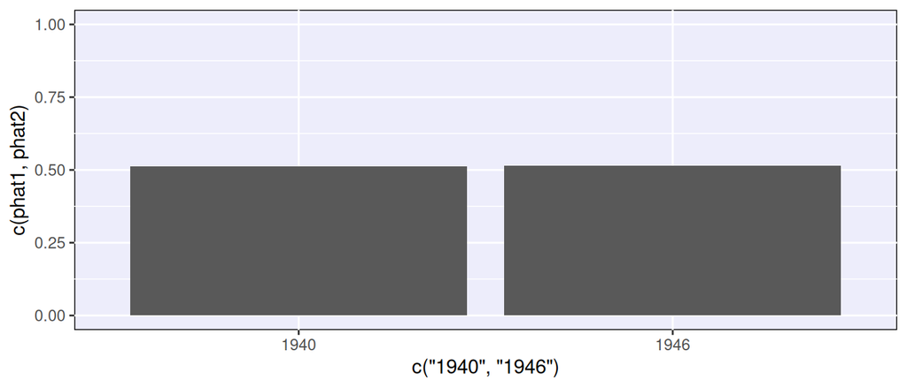

```r
# Counts of total births and boy births
n1 <- 1211684 + 1148715
x1 <- 1211684
n2 <- 1691220 + 1597452
x2 <- 1691220

phat1 <- x1/n1
phat2 <- x2/n2

ggplot(mapping = aes(x = c("1940", "1946"), y = c(phat1, phat2))) +
  geom_col() +
  coord_cartesian(ylim = c(0, 1))
```

2. Re-create the plot in part (a) but set the y-axis to go from 0.51 to 0.52.

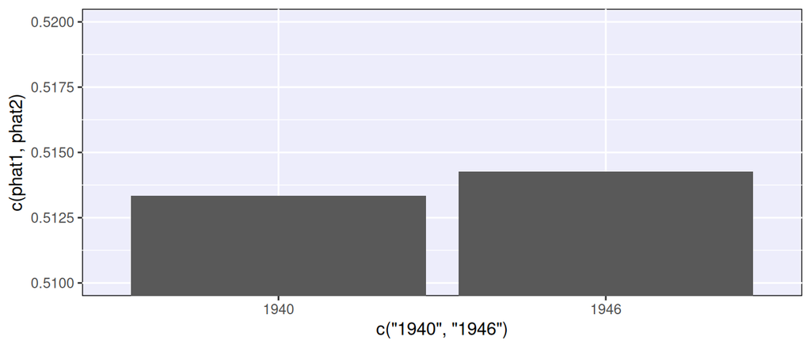

```r
ggplot(mapping = aes(x = c("1940", "1946"), y = c(phat1, phat2))) +
  geom_col() +
  coord_cartesian(ylim = c(0.51, 0.52))
```

3. Before calculating a statistical result, do you think that this data is suggestive of a difference in the proportion of boys born between 1940 and 1946? Which plot do you think does a better job of illustrating the data in context?

I am uncertain about whether there will be a significant result, because the difference between $\hat{p}_1$ and $\hat{p}_2$ is very small, but the sample sizes are so large that we might get a large Z test statistic anyway (from the standard error being so small). I think that it is difficult to make intuitive statements about numbers at this scale.

I think that the second plot does a better job at illustrating the plot in context, because the scale in the first plot is much too wide. It doesn’t make sense for “proportion of male births” to be anywhere close to 0 or 1 so it would be odd to set the y axis to that range. On the other hand, one could argue that the second plot is so zoomed in that it overstates the difference between the two years.

# Problem 4

Build a 95% confidence interval on the difference in proportion of male births between 1940 and 1946 and interpret your results in context.

```r
# Counts of total births and boy births
n1 <- 1211684 + 1148715
x1 <- 1211684
n2 <- 1691220 + 1597452
x2 <- 1691220

phat1 <- x1/n1
phat2 <- x2/n2

pt_est <- phat1 - phat2

# Standard error with AC adjustment
se <- sqrt(phat1*(1 - phat1)/n1 + phat2*(1 - phat2)/n2)

# Critical value
cv <- qnorm(0.975)
```

The point estimate is the observed difference in proportions, which is about -0.0009. The standard error of the difference is 0.0004. Finally, the Z critical value for 95% confidence is $z_{0.025} = 1.96$.

```r
# Find upper and lower bounds of interval
c(pt_est - cv*se, pt_est + cv*se)
```

```
## [1] -1.753255e-03 -8.189605e-05
```

# Problem 5

Perform a hypothesis test to determine whether the proportion of male births in the US in 1946 is different from the proportion of male births in the US in 1940. Write appropriate two-sided hypotheses and draw a conclusion with $\alpha = 0.05$.

```r
# Counts of total births and boy births
n1 <- 1211684 + 1148715
x1 <- 1211684
n2 <- 1691220 + 1597452
x2 <- 1691220

p_hat <- (x1 + x2)/(n1 + n2) # Estimated common proportion

numerator <- (x1/n1) - (x2/n2)  # Observed difference in proportions

denominator <- sqrt(p_hat*(1-p_hat)*(1/n1 + 1/n2))  # SE using common proportion

test_stat <- numerator/denominator
test_stat
```

```
## [1] -2.152056
```

We get an observed test statistic of $\frac{\hat{p}_{boy, 1940} - \hat{p}_{boy, 1946}}{\hat{se}} = -2.152$. Under $H_0$, this value was drawn from a standard normal curve. For our two-sided p-value, we calculate $2\times P(Z < -2.152)$.

```r
2*pnorm(-2.152)
```

```
## [1] 0.03139735
```

We get a p-value of 0.03 which is smaller than $\alpha = 0.05$, so we reject $H_0$. We have evidence of a greater proportion of boys born in the US in 1946 compared to 1940, although it is only moderately strong evidence.

# Problem 6

Consider the assumptions for the two-sample proportion Z test done in problems 4 and 5. For each of the following parts, identify whether the assumption described is **necessary** or **not necessary** for a two-sample proportion Z test to be valid. Briefly explain each of your answers.

1. BINS assumptions are separately met for the births in 1940 and the births in 1946.

This is necessary. The proportion Z test is based on the normal approximation to a binomial, so it is only accurate if “number of boys born in 1940” and “number of boys born in 1946” are both well-modeled by a binomial.

2. BINS assumptions are met for the entire set of births in both 1940 and 1946.

This is not necessary. The binomial model applies separately to both groups, but not to all of the observations pooled together. Specifically, we do not need to have the same $p$ across both years.

3. The difference in population proportions $p_1 - p_2$ is approximately normal.

This is not necessary. We assume that $p_1 - p_2$ is a fixed, unknown quantity, not a normal random variable.

4. The difference in population proportions $p_1 - p_2$ is zero.

This is not necessary. We are making this assumption as our null hypothesis, but it does not need to be true in order for the test to be valid. This is the statement we are trying to test.

5. The difference in sample proportions $\hat{p}_1 - \hat{p}_2$ is approximately normal.

This is necessary. The construction of the Z test statistic relies on assuming that $\hat{p}_1 - \hat{p}_2$ has a normal sampling distribution. This is reasonable to assume if we have a large sample size in both groups.

# Problem 7

Explain why an approximate Z test can be performed when doing proportion inference, but not a T test. *(Think about the difference between the T and Z test in the context of mean inference - why does this not apply to a proportion?)*

A T test is a slightly more conservative (less likely to reject) version of a Z test that uses a wider curve as a null distribution. This represents the additional error we incur when we have to estimate $\sigma$, the population SD, with $S$, the sample SD.

In the context of mean inference, the population mean $\mu$ and population sd $\sigma$ are two separate parameters.

In proportion inference, we have no separate $\sigma$ parameter. Instead, the standard error term is also a function of $\hat{p}$, the parameter of interest. So, we are not technically estimating any additional parameters, just $\hat{p}$, so we do not use a T distribution.

# Problem 8

Continue working with the `mtcars` example from lecture. Suppose that the rows in the `mtcars` data represent the miles per gallon a full population of the cars.

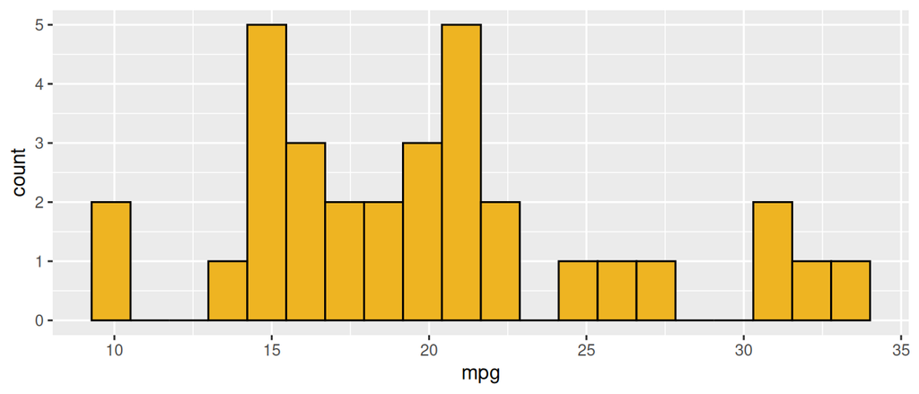

```r
ggplot(mtcars, aes(x = mpg)) +
  geom_histogram(fill = "goldenrod2", color = "black", bins = 20)
```

The mpg has a population mean of $\mu = 20.09$ and a population standard deviation of $\sigma = 5.932$.

```r
mean(mtcars$mpg)
```

```
## [1] 20.09062
```

```r
size <- nrow(mtcars)
sqrt( ((size-1)/size)*var(mtcars$mpg) )
```

```
## [1] 5.93203
```

1. Use `replicate()` to draw 10000 samples of size $n = 10$ from `mtcars`. For each one, calculate the quantity

$$z \;=\; \frac{\bar{x} -
\mu}{\sigma/\sqrt{n}}$$

where $\bar{x}$ is the mean of the sample. Save these values in a dataframe or vector called `z_scores`. You can use the function `new_data()` from lecture to help you.

```r
new_data <- function(data, n) {
  sample_n(data, size = n, replace = TRUE)
}
```

```r
z_scores <- tibble(
  xbar = replicate(10000, mean(new_data(mtcars, 10)$mpg)),
  z = (xbar - 20.09) / (5.932/sqrt(10))
)
```

2. Create a histogram of the 10000 simulated $z$ values from part (a). Verify visually that the result is similar to a $N(0, 1)$ standard normal curve. You should see a bell curve centered at 0 with most of the histogram area between -3 and 3.

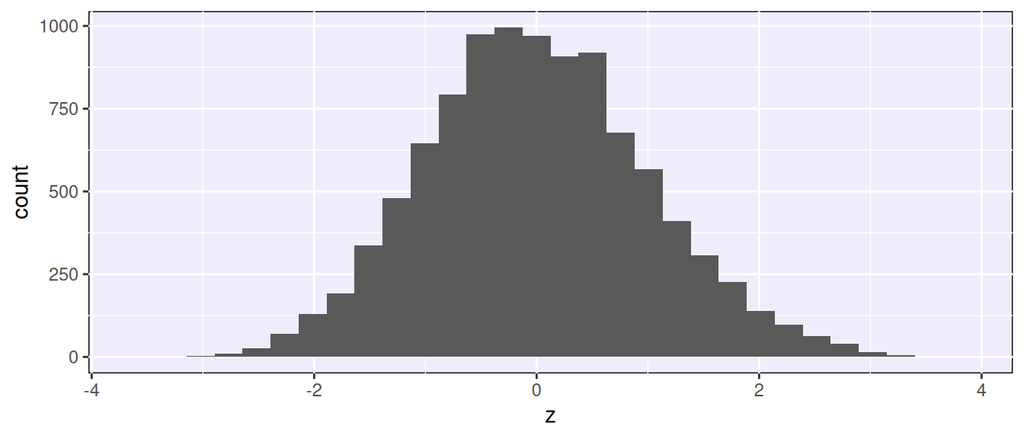

```r
ggplot(z_scores, aes(x = z)) +
  geom_histogram()
```

3. What is the 70th percentile of the simulated $z$ values? Compare this to the exact 70th percentile of $N(0, 1)$.

```r
quantile(z_scores$z, probs = 0.7)
```

```
##       70%
## 0.5064335
```

```r
qnorm(0.7)
```

```
## [1] 0.5244005
```

The 70th percentile of the simulations is very similar to the 70th percentile of a normal curve, which is 0.524.

4. Now, imagine if we had instead calculated

$$t \;=\; \frac{\bar{x} -
\mu}{s/\sqrt{n}}$$

where $s$ is the sample standard deviation. How would the histogram of the simulated $t$ values compare to the histogram of simulated $z$ values in (b)? How would the 70th percentile of the simulated $t$ values compare to the 70th percentile calculated in (c)?

You should **not** need to actually perform this simulation - the answers to part (d) can be found by thinking through the concept of a T distribution.